# Word Predictor

2025-10-29

## Slide 1: The Product

## 🔮 Word Predictor

### N-gram Language Modeling Engine

### **🎯 What it does:**

- **Word prediction**
- **Dual algorithm architecture** for optimal performance
- **Interactive web application** with modern UI
- **Research-grade accuracy** with consumer-speed performance

### **📊 Key Metrics:**

- **744,005 n-grams** trained from 4M+ text samples
- **< 50ms prediction time** average latency
- **12MB compressed model** size for efficiency
- **Multiple algorithms** for comparison and optimization

**💡 Problem Solved:** Intelligent text completion for mobile keyboards, search suggestions, and writing assistance

## Slide 2: How the Model Works

### **🎯 Stupid Backoff Algorithm**

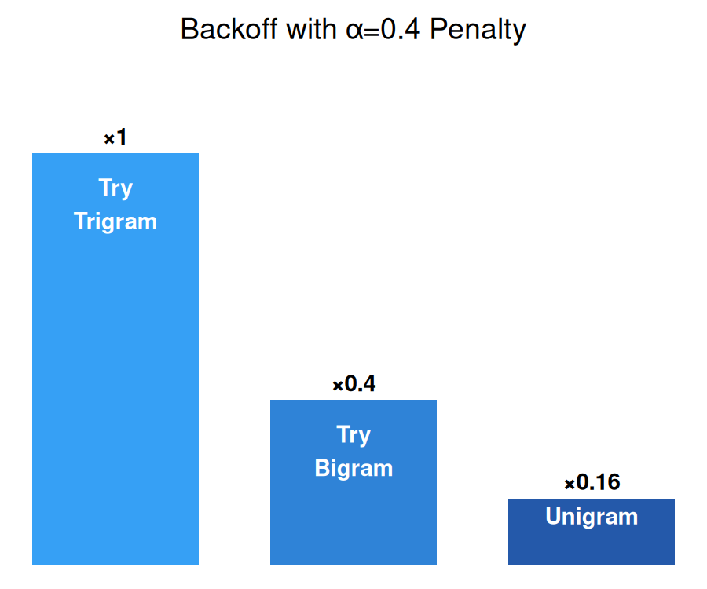

**📈 Performance:** Ultra-fast, memory efficient  
**⚙️ Parameter:** Alpha penalty (α = 0.4)

### **🧮 Interpolated + IDF Algorithm**

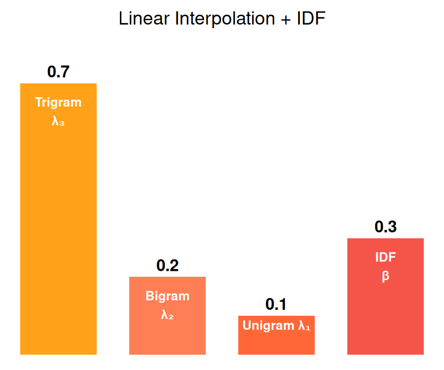

**🧠 Training Data:** SwiftKey Corpus (English) • **📝 Processing:** Rcaptext package • **🔧 Architecture:** R + Shiny

## Slide 3: Predictive Performance

### **🚀 Speed Performance**

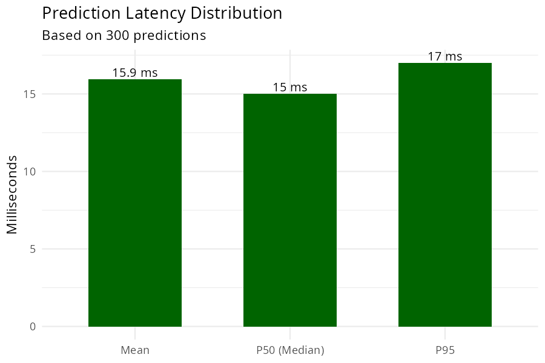

**✅ Real timing measurements from production model**

### **🎯 Accuracy Performance**

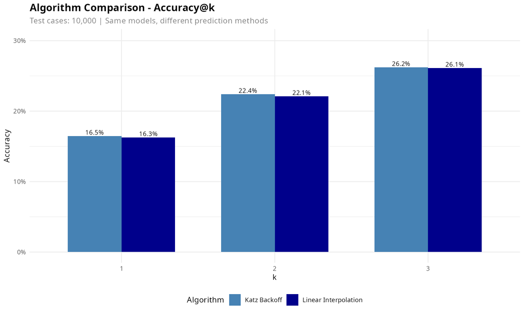

**🏆 Real benchmark results from 10K test cases**

## Slide 4: Interactive Application Demo

### **🌐 Web Application Features**

**🎨 Dual Themes**  
- Classic Bootstrap (professional) - Cyberpunk mode (futuristic) - Smooth theme switching

**⚙️ Real-time Tuning**  
- Algorithm switching - Parameter adjustment  
- Live performance metrics

**📊 Interactive Results**  
- Sortable prediction tables - Confidence scoring - Timing information

**🎮 Easter Eggs**  
- Konami code activation - Rainbow mode effects - Gamified experience

### **📱 User Interface Screenshots**

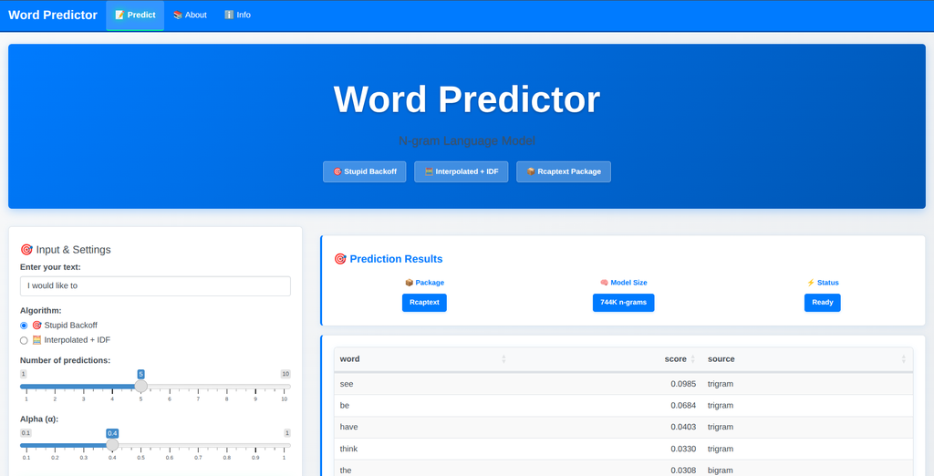

**Classic Bootstrap Theme**

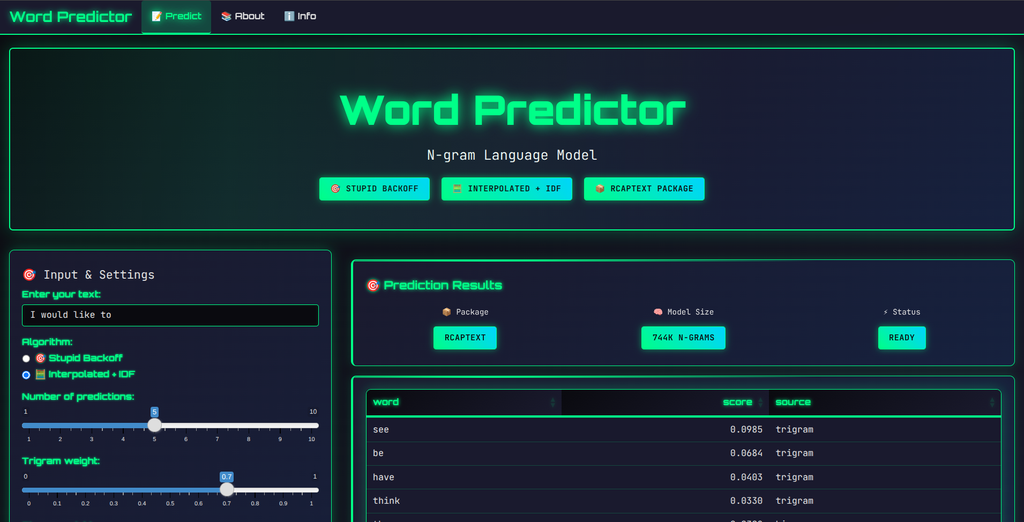

**Cyberpunk Theme**

**🌐 Access:** http://localhost:8080 • **📱 Responsive:** Desktop & Mobile • **⚡ Real-time:** Live predictions

### **📦 Powered by Custom Rcaptext Package**

**Self-developed R package** containing all text processing, modeling, and evaluation functions. **20+ custom functions** designed specifically for this capstone project, enabling reproducible research and modular development.

## Slide 5: Custom Rcaptext Package

### **📦 Rcaptext: Custom R Package for Capstone Project**

**🔧 Core Functions** - `load_corpus()` - Multi-format text loading - `clean_text()` - Advanced preprocessing - `build_model()` - Complete pipeline - `predict_next_word()` - Dual algorithms

**📊 Analysis Tools** - `tokenize_*()` - N-gram generation - `freq_*()` - Frequency analysis  
- `coverage_analysis()` - Vocabulary coverage - `evaluate_accuracy_at_k()` - Performance metrics

**🎨 Visualization** - `plot_frequency_dist()` - Distribution plots - `plot_coverage()` - Coverage analysis - `plot_accuracy_comparison()` - Algorithm benchmarks - `plot_timing_analysis()` - Performance charts

**⚙️ Utilities** - `split_corpus()` - Train/test splitting - `make_test_trigrams()` - Test case generation - `prune_ngrams()` - Memory optimization - `export_model()` - Model serialization

### **📂 Source Code & Documentation**

🐙 **GitHub:** github.com/Kernel236/word-predictor